# Języki skryptowe w analizie danych - biblioteka `pandas`

###### dr inż. Marcin Lawnik, mgr inż. Arkadiusz Banasik

### Zestaw 1:

1. Wczytaj plik `nauczyciele.csv`, w którym znajdują się dane odnośnie zatrudnienia nauczycieli akademickich w Polsce w wybranych latach, z podziałem na stanowisko i płeć. Rozróżnione są dodatkowo uniwersystety i szkoły techniczne.
2. Przygotuj dane do dalszej analizy (usuń zbędne wiersze i kolumny, zwróć uwagę na typ danych)
3. Stwórz następujące wykresy:
   - zestawienie nauczycieli akademickich zatrudnionych na dowolnym etacie w latach 2014-2018 z podziałem na województwo
   - zestawienie różnych stanowisk (asystenci, adiunkcji, profesorowie) zatrudnionych w latach 2014-2018 w województwie śląskim
   - zestawienie nauczycieli akademickich zatrudnionych na uniwersytetach i szkołach technicznych z podziałem na płcie w województwie śląskim
4. W danych znajdź:
   - wartości dla województwa śląskiego
   - województwa, w których jest zatrudnionych najwięcej i najmniej nauczycieli akademickich
   - województwa, które zatrudniają kobiety ponad średnią

### Zestaw 2:

1. Wczytaj plik `inflacja.xlsx`, w którym znajdują się dane dotyczące poziomu inflacji w Polsce (kolejne skoroszyty).
2. Przygotuj dane do dalszej analizy (usuń zbędne wiersze i kolumny, zwróć uwagę na typ danych).
3. Stwórz następujące wykresy:
   - zestawienie roku 2017, 2018 i 2019 w odniesieniu do grudnia poprzeniego roku (Table 1)
   - zestawienie października roku 2017, 2018 i 2019 w odniesieniu do poprzeniego miesiąca danego roku (Table 2)
   - zestawienie roku 2017, 2018 i 2019 w odniesieniu do analogicznego miesiąca poprzedniego roku (Table 3)
4. W danych znajdź:
   - wartości największa i najmniejszą w każdej kategorii
   - wyznacz nawyższe wartości inflacji w poszczególnych latach
   - wyznacz średnią wartośc inflacji w poszczególnych latach

**Uwaga**

Na Platformę Zdalnej Edukacji należy wysłać rozwiązanie co najmniej 1 zestawu (min. 3 pkt). Wysyłamy pliki *ipynb* i *html*.

## Zestaw 1

### zad 1

```python
import pandas as pd

# Zadanie 1
teachers = pd.read_csv("C:\\Users\\Dawid\\Desktop\\semestr6\\jezyki skryptowe w analizie danych\\nauczyciele.csv", sep=";", decimal=",", index_col="Nazwa")
teachers
```

| Nazwa | Kod | nauczyciele akademiccy;ogółem;uniwersytety;2014;[osoba] | nauczyciele akademiccy;ogółem;uniwersytety;2015;[osoba] | nauczyciele akademiccy;ogółem;uniwersytety;2016;[osoba] | nauczyciele akademiccy;ogółem;uniwersytety;2017;[osoba] | nauczyciele akademiccy;ogółem;uniwersytety;2018;[osoba] | nauczyciele akademiccy;ogółem;wyższe szkoły techniczne;2014;[osoba] | nauczyciele akademiccy;ogółem;wyższe szkoły techniczne;2015;[osoba] | nauczyciele akademiccy;ogółem;wyższe szkoły techniczne;2016;[osoba] | nauczyciele akademiccy;ogółem;wyższe szkoły techniczne;2017;[osoba] | ... | asystenci;kobiety;uniwersytety;2015;[osoba] | asystenci;kobiety;uniwersytety;2016;[osoba] | asystenci;kobiety;uniwersytety;2017;[osoba] | asystenci;kobiety;uniwersytety;2018;[osoba] | asystenci;kobiety;wyższe szkoły techniczne;2014;[osoba] | asystenci;kobiety;wyższe szkoły techniczne;2015;[osoba] | asystenci;kobiety;wyższe szkoły techniczne;2016;[osoba] | asystenci;kobiety;wyższe szkoły techniczne;2017;[osoba] | asystenci;kobiety;wyższe szkoły techniczne;2018;[osoba] | Unnamed: 102 |
| --- | --- | --- | --- | --- | --- | --- | --- | --- | --- | --- | --- | --- | --- | --- | --- | --- | --- | --- | --- | --- | --- |
| POLSKA | 0 | 31928.1 | 31700.2 | 31838.5 | 31991.3 | 31560.8 | 19959.6 | 19804.8 | 19701.9 | 19530.1 | ... | 2202.0 | 2303.6 | 2415.6 | 2215.3 | 1050.6 | 1066.2 | 1081.2 | 1072.6 | 937.0 | NaN |
| DOLNOŚLĄSKIE | 200000 | 1837.7 | 1856.7 | 1884.5 | 1919.2 | 1930.9 | 2003.3 | 2028.6 | 2051.7 | 2080.3 | ... | 46.6 | 58.3 | 66.0 | 65.7 | 108.8 | 108.5 | 111.5 | 107.3 | 99.2 | NaN |
| KUJAWSKO-POMORSKIE | 400000 | 2689.9 | 2651.1 | 2647.4 | 2721.4 | 2684.8 | 0.0 | 0.0 | 0.0 | 0.0 | ... | 262.7 | 276.8 | 311.2 | 258.8 | 0.0 | 0.0 | 0.0 | 0.0 | 0.0 | NaN |
| LUBELSKIE | 600000 | 2912.0 | 2770.8 | 2721.5 | 2648.5 | 2578.0 | 549.0 | 568.9 | 587.7 | 581.8 | ... | 265.0 | 269.5 | 243.5 | 230.9 | 42.0 | 42.0 | 49.0 | 47.0 | 47.0 | NaN |
| LUBUSKIE | 800000 | 899.0 | 884.5 | 920.0 | 1000.5 | 982.5 | 0.0 | 0.0 | 0.0 | 0.0 | ... | 47.5 | 54.5 | 61.0 | 22.0 | 0.0 | 0.0 | 0.0 | 0.0 | 0.0 | NaN |
| ŁÓDZKIE | 1000000 | 2188.2 | 2159.2 | 2145.6 | 2157.7 | 2135.4 | 1432.6 | 1396.4 | 1368.7 | 1321.8 | ... | 133.2 | 133.5 | 130.8 | 121.9 | 41.5 | 42.3 | 31.7 | 29.3 | 21.8 | NaN |
| MAŁOPOLSKIE | 1200000 | 3879.4 | 3932.9 | 4022.4 | 4119.2 | 4120.7 | 3444.0 | 3395.2 | 3382.0 | 3351.9 | ... | 440.2 | 454.7 | 513.9 | 513.1 | 212.3 | 230.7 | 231.0 | 228.6 | 192.7 | NaN |
| MAZOWIECKIE | 1400000 | 4196.0 | 4259.0 | 4303.5 | 4332.0 | 4285.4 | 3055.9 | 3037.6 | 3045.2 | 3033.4 | ... | 174.8 | 206.0 | 229.3 | 229.1 | 112.2 | 108.5 | 115.0 | 115.8 | 124.6 | NaN |
| OPOLSKIE | 1600000 | 696.4 | 688.7 | 678.0 | 687.3 | 666.1 | 504.2 | 512.1 | 505.0 | 494.2 | ... | 21.0 | 18.0 | 20.6 | 15.1 | 41.6 | 39.1 | 35.0 | 29.0 | 23.0 | NaN |
| PODKARPACKIE | 1800000 | 1275.8 | 1290.1 | 1306.6 | 1299.0 | 1253.7 | 771.0 | 771.4 | 777.8 | 856.0 | ... | 114.8 | 127.5 | 139.5 | 115.5 | 56.2 | 54.8 | 57.3 | 72.3 | 70.3 | NaN |
| PODLASKIE | 2000000 | 776.1 | 753.8 | 747.7 | 760.9 | 763.3 | 663.7 | 648.3 | 643.7 | 647.0 | ... | 111.2 | 112.0 | 126.0 | 132.0 | 48.8 | 46.5 | 44.0 | 38.5 | 26.3 | NaN |
| POMORSKIE | 2200000 | 1670.6 | 1700.5 | 1685.8 | 1720.9 | 1735.4 | 1220.7 | 1217.5 | 1230.0 | 1247.1 | ... | 109.3 | 107.9 | 123.6 | 124.3 | 48.1 | 51.1 | 61.5 | 69.7 | 70.9 | NaN |
| ŚLĄSKIE | 2400000 | 1940.9 | 1941.2 | 1950.4 | 1930.2 | 1887.7 | 3040.3 | 2983.5 | 2925.3 | 2816.8 | ... | 145.7 | 151.0 | 138.5 | 113.8 | 106.3 | 110.1 | 107.1 | 99.1 | 93.7 | NaN |
| ŚWIĘTOKRZYSKIE | 2600000 | 856.0 | 850.4 | 872.4 | 885.1 | 868.1 | 474.3 | 495.9 | 498.2 | 480.1 | ... | 45.0 | 44.0 | 47.0 | 61.0 | 61.0 | 74.0 | 69.0 | 68.0 | 5.0 | NaN |
| WARMIŃSKO-MAZURSKIE | 2800000 | 1994.0 | 1924.1 | 1908.2 | 1834.5 | 1791.8 | 0.0 | 0.0 | 0.0 | 0.0 | ... | 161.0 | 175.9 | 169.2 | 134.8 | 0.0 | 0.0 | 0.0 | 0.0 | 0.0 | NaN |
| WIELKOPOLSKIE | 3000000 | 2963.9 | 2918.3 | 2929.8 | 2881.9 | 2843.7 | 1278.8 | 1286.0 | 1274.0 | 1276.7 | ... | 13.0 | 13.5 | 8.5 | 5.0 | 90.8 | 97.1 | 101.8 | 106.5 | 111.2 | NaN |
| ZACHODNIOPOMORSKIE | 3200000 | 1152.2 | 1118.9 | 1114.7 | 1093.0 | 1033.3 | 1521.8 | 1463.4 | 1412.6 | 1343.0 | ... | 111.0 | 100.5 | 87.0 | 72.3 | 81.0 | 61.5 | 67.3 | 61.5 | 51.3 | NaN |

17 rows × 102 columns

### zad 2

```python
import numpy as np

teachers_ready = teachers.drop(["Unnamed: 102", "Kod"], axis=1).drop(["POLSKA"], axis=0)
cols = np.array([col.split(';')[:-1] for col in teachers_ready.columns]).transpose()
t_multiindex = pd.MultiIndex.from_arrays(cols, names=["Kto", "Plec", "Gdzie", "Rok"])
teachers_ready.columns = t_multiindex
teachers_ready
```

| Kto Plec Gdzie Rok Nazwa | nauczyciele akademiccy ogółem uniwersytety 2014 | nauczyciele akademiccy ogółem uniwersytety 2015 | nauczyciele akademiccy ogółem uniwersytety 2016 | nauczyciele akademiccy ogółem uniwersytety 2017 | nauczyciele akademiccy ogółem uniwersytety 2018 | nauczyciele akademiccy ogółem wyższe szkoły techniczne 2014 | nauczyciele akademiccy ogółem wyższe szkoły techniczne 2015 | nauczyciele akademiccy ogółem wyższe szkoły techniczne 2016 | nauczyciele akademiccy ogółem wyższe szkoły techniczne 2017 | nauczyciele akademiccy ogółem wyższe szkoły techniczne 2018 | ... | asystenci kobiety uniwersytety 2014 | asystenci kobiety uniwersytety 2015 | asystenci kobiety uniwersytety 2016 | asystenci kobiety uniwersytety 2017 | asystenci kobiety uniwersytety 2018 | asystenci kobiety wyższe szkoły techniczne 2014 | asystenci kobiety wyższe szkoły techniczne 2015 | asystenci kobiety wyższe szkoły techniczne 2016 | asystenci kobiety wyższe szkoły techniczne 2017 | asystenci kobiety wyższe szkoły techniczne 2018 |
| --- | --- | --- | --- | --- | --- | --- | --- | --- | --- | --- | --- | --- | --- | --- | --- | --- | --- | --- | --- | --- | --- |
| DOLNOŚLĄSKIE | 1837.7 | 1856.7 | 1884.5 | 1919.2 | 1930.9 | 2003.3 | 2028.6 | 2051.7 | 2080.3 | 2043.1 | ... | 28.6 | 46.6 | 58.3 | 66.0 | 65.7 | 108.8 | 108.5 | 111.5 | 107.3 | 99.2 |
| KUJAWSKO-POMORSKIE | 2689.9 | 2651.1 | 2647.4 | 2721.4 | 2684.8 | 0.0 | 0.0 | 0.0 | 0.0 | 0.0 | ... | 272.0 | 262.7 | 276.8 | 311.2 | 258.8 | 0.0 | 0.0 | 0.0 | 0.0 | 0.0 |
| LUBELSKIE | 2912.0 | 2770.8 | 2721.5 | 2648.5 | 2578.0 | 549.0 | 568.9 | 587.7 | 581.8 | 583.8 | ... | 283.0 | 265.0 | 269.5 | 243.5 | 230.9 | 42.0 | 42.0 | 49.0 | 47.0 | 47.0 |
| LUBUSKIE | 899.0 | 884.5 | 920.0 | 1000.5 | 982.5 | 0.0 | 0.0 | 0.0 | 0.0 | 0.0 | ... | 49.0 | 47.5 | 54.5 | 61.0 | 22.0 | 0.0 | 0.0 | 0.0 | 0.0 | 0.0 |
| ŁÓDZKIE | 2188.2 | 2159.2 | 2145.6 | 2157.7 | 2135.4 | 1432.6 | 1396.4 | 1368.7 | 1321.8 | 1234.8 | ... | 134.7 | 133.2 | 133.5 | 130.8 | 121.9 | 41.5 | 42.3 | 31.7 | 29.3 | 21.8 |
| MAŁOPOLSKIE | 3879.4 | 3932.9 | 4022.4 | 4119.2 | 4120.7 | 3444.0 | 3395.2 | 3382.0 | 3351.9 | 3246.4 | ... | 420.6 | 440.2 | 454.7 | 513.9 | 513.1 | 212.3 | 230.7 | 231.0 | 228.6 | 192.7 |
| MAZOWIECKIE | 4196.0 | 4259.0 | 4303.5 | 4332.0 | 4285.4 | 3055.9 | 3037.6 | 3045.2 | 3033.4 | 2991.0 | ... | 147.6 | 174.8 | 206.0 | 229.3 | 229.1 | 112.2 | 108.5 | 115.0 | 115.8 | 124.6 |
| OPOLSKIE | 696.4 | 688.7 | 678.0 | 687.3 | 666.1 | 504.2 | 512.1 | 505.0 | 494.2 | 465.7 | ... | 22.5 | 21.0 | 18.0 | 20.6 | 15.1 | 41.6 | 39.1 | 35.0 | 29.0 | 23.0 |
| PODKARPACKIE | 1275.8 | 1290.1 | 1306.6 | 1299.0 | 1253.7 | 771.0 | 771.4 | 777.8 | 856.0 | 863.1 | ... | 97.2 | 114.8 | 127.5 | 139.5 | 115.5 | 56.2 | 54.8 | 57.3 | 72.3 | 70.3 |
| PODLASKIE | 776.1 | 753.8 | 747.7 | 760.9 | 763.3 | 663.7 | 648.3 | 643.7 | 647.0 | 615.8 | ... | 109.2 | 111.2 | 112.0 | 126.0 | 132.0 | 48.8 | 46.5 | 44.0 | 38.5 | 26.3 |
| POMORSKIE | 1670.6 | 1700.5 | 1685.8 | 1720.9 | 1735.4 | 1220.7 | 1217.5 | 1230.0 | 1247.1 | 1219.3 | ... | 102.5 | 109.3 | 107.9 | 123.6 | 124.3 | 48.1 | 51.1 | 61.5 | 69.7 | 70.9 |
| ŚLĄSKIE | 1940.9 | 1941.2 | 1950.4 | 1930.2 | 1887.7 | 3040.3 | 2983.5 | 2925.3 | 2816.8 | 2731.9 | ... | 139.0 | 145.7 | 151.0 | 138.5 | 113.8 | 106.3 | 110.1 | 107.1 | 99.1 | 93.7 |
| ŚWIĘTOKRZYSKIE | 856.0 | 850.4 | 872.4 | 885.1 | 868.1 | 474.3 | 495.9 | 498.2 | 480.1 | 456.7 | ... | 48.0 | 45.0 | 44.0 | 47.0 | 61.0 | 61.0 | 74.0 | 69.0 | 68.0 | 5.0 |
| WARMIŃSKO-MAZURSKIE | 1994.0 | 1924.1 | 1908.2 | 1834.5 | 1791.8 | 0.0 | 0.0 | 0.0 | 0.0 | 0.0 | ... | 168.0 | 161.0 | 175.9 | 169.2 | 134.8 | 0.0 | 0.0 | 0.0 | 0.0 | 0.0 |
| WIELKOPOLSKIE | 2963.9 | 2918.3 | 2929.8 | 2881.9 | 2843.7 | 1278.8 | 1286.0 | 1274.0 | 1276.7 | 1288.1 | ... | 10.5 | 13.0 | 13.5 | 8.5 | 5.0 | 90.8 | 97.1 | 101.8 | 106.5 | 111.2 |
| ZACHODNIOPOMORSKIE | 1152.2 | 1118.9 | 1114.7 | 1093.0 | 1033.3 | 1521.8 | 1463.4 | 1412.6 | 1343.0 | 1249.9 | ... | 124.5 | 111.0 | 100.5 | 87.0 | 72.3 | 81.0 | 61.5 | 67.3 | 61.5 | 51.3 |

16 rows × 100 columns

### zad 3

```
a)
```

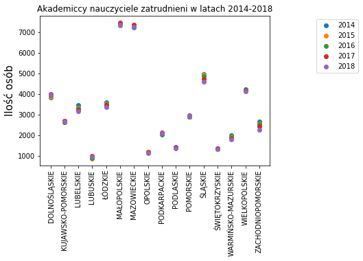

```
b)
```

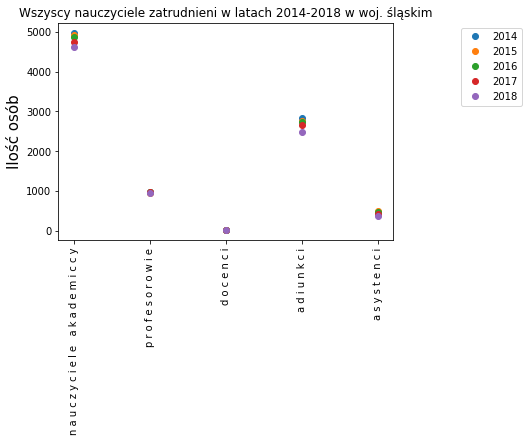

```
c)
```

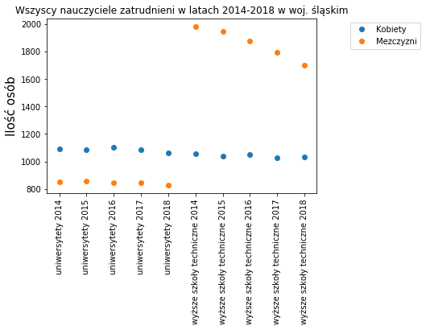

```python
import matplotlib.pyplot as plt

print("a)")
data = teachers_ready.xs(['nauczyciele akademiccy', 'ogółem'], level=('Kto', 'Plec'), axis=1)["uniwersytety"] + teachers_ready.xs(['nauczyciele akademiccy', 'ogółem'], level=('Kto', 'Plec'), axis=1)["wyższe szkoły techniczne"]

plt.plot(range(len(data)), data,'o')
plt.xticks(range(len(data.index)), data.index, rotation=90)
plt.title('Akademiccy nauczyciele zatrudnieni w latach 2014-2018')
plt.ylabel('Ilość osób', fontsize=15)
plt.legend([2014, 2015, 2016, 2017, 2018], bbox_to_anchor=(1.4, 1))

plt.show()
plt.close()

print("b)")
x_ticks = list(dict.fromkeys(teachers_ready.columns.get_level_values(0)))
data = list()
for el in x_ticks:
    data.append((teachers_ready.xs([el, 'ogółem'], level=('Kto', 'Plec'), axis=1)["uniwersytety"] + teachers_ready.xs([el, 'ogółem'], level=('Kto', 'Plec'), axis=1)["wyższe szkoły techniczne"]).loc["ŚLĄSKIE"])

for i in range(len(x_ticks)):
    x_ticks[i] = " ".join(x_ticks[i])

plt.plot(range(len(data)), data, 'o')
plt.xticks(range(len(x_ticks)), x_ticks, rotation=90)
plt.title('Wszyscy nauczyciele zatrudnieni w latach 2014-2018 w woj. śląskim')
plt.ylabel('Ilość osób', fontsize=15)
plt.legend([2014, 2015, 2016, 2017, 2018], bbox_to_anchor=(1.4, 1))

plt.show()
plt.close()

print("c)")

men = (teachers_ready.xs(['nauczyciele akademiccy'], level=('Kto'), axis=1)["ogółem"] - teachers_ready.xs(['nauczyciele akademiccy'], level=('Kto'), axis=1)["kobiety"]).loc["ŚLĄSKIE"]
women = (teachers_ready.xs(['nauczyciele akademiccy'], level=('Kto'), axis=1)["kobiety"]).loc["ŚLĄSKIE"]

x_ticks = list()
for el in men.index:
    x_ticks.append(" ".join(el))

plt.plot(range(len(women)), women, 'o')
plt.plot(range(len(men)), men, 'o')
plt.xticks(range(len(x_ticks)), x_ticks, rotation=90)
plt.title('Wszyscy nauczyciele zatrudnieni w latach 2014-2018 w woj. śląskim')
plt.ylabel('Ilość osób', fontsize=15)
plt.legend(["Kobiety", "Mezczyzni"], bbox_to_anchor=(1.4, 1))

plt.show()
plt.close()
```